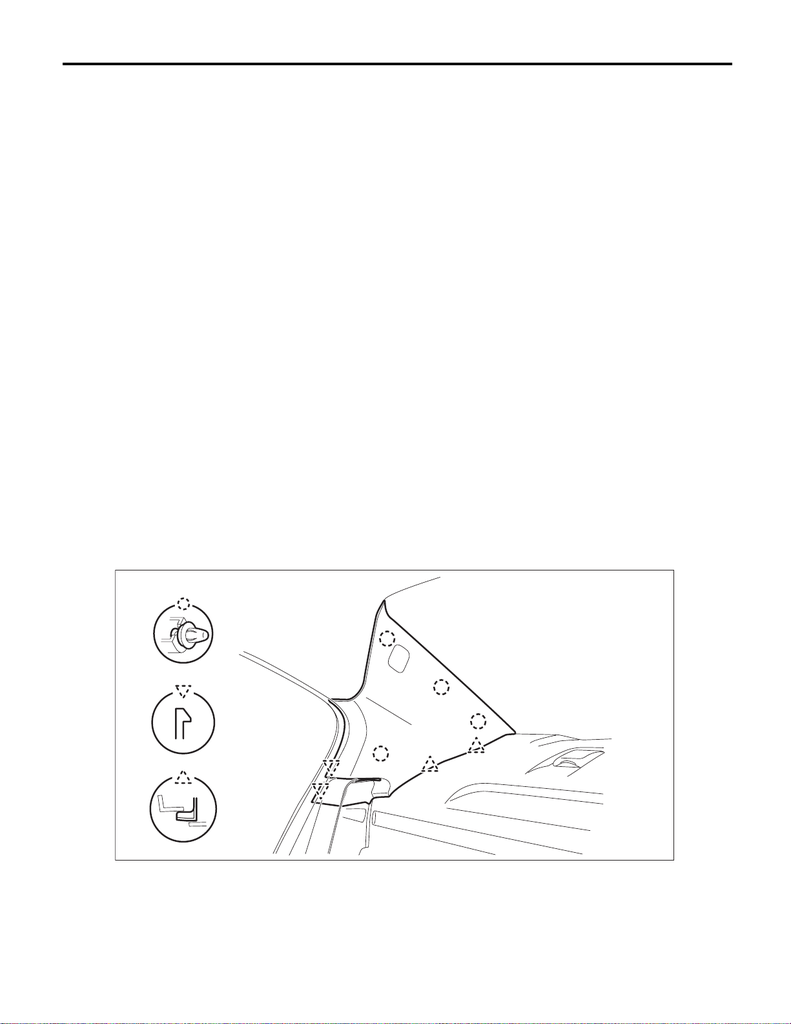

EI-99

Roof Trim

EXTERIOR/INTERIOR TRIM

30.Roof Trim

A: REMOVAL

CAUTION:

• Airbag system satellite safing sensor is located in the lower of the rear seat cushion center. Before

removing the rear seat, refer to “CAUTION” of “General Description” in “AIRBAG SYSTEM” section.

<Ref. to AB-9, CAUTION, General Description.>

• The airbag system is fitted with a backup power supply. After disconnecting the battery ground ca-

ble, the airbag may operate if you do not wait for 60 seconds before starting the service of airbag sys-

tem.

1) Adjust the passenger’s seat position.

(1) Remove the headrest.

(2) Move the passenger’s seat to the front-most position and tilt the backrest rearward.

2) Disconnect the ground cable from battery and wait for at least 60 seconds before starting work. <Ref. to

NT-5, BATTERY, NOTE, Note.>

NOTE:

• For models other than STI model, disconnect the ground terminal from battery sensor.

• On CVT models, shift the select lever into “D” before disconnecting the battery ground cable.

• For model with power seat, adjust the passenger’s seat to the specified position, and remove the driver’s

seat and then disconnect the battery ground terminal.

3) Remove the driver’s seat. <Ref. to SE-9, REMOVAL, Front Seat.>

4) Remove the console box assembly and the cover - shift lever. <Ref. to EI-67, REMOVAL, Console Box.>

5) Cover the following areas to protect from damage.

• Steering wheel surface

• Instrument panel surface

• Glove box surface

6) Remove the rear seat cushion assembly. <Ref. to SE-29, REMOVAL, Rear Seat.>

7) Remove the lower inner trim on the RH and LH sides. <Ref. to EI-81, REMOVAL, Lower Inner Trim.>

8) Remove the upper inner trim on the RH and LH sides. <Ref. to EI-85, REMOVAL, Upper Inner Trim.>

9) Remove the clips, and remove the trim panel - rear pillar UPR on the left and right sides.

10) Remove the light assembly - map. <Ref. to LI-60, REMOVAL, Spot Map Light.>

11) Remove the left and right sun visor assembly. <Ref. to EI-97, REMOVAL, Sun Visor.>

12) Remove the light assembly - room. <Ref. to LI-62, REMOVAL, Room Light.>

13) Remove all assist rails. <Ref. to EI-98, REMOVAL, Assist Grip.>

EI-03455

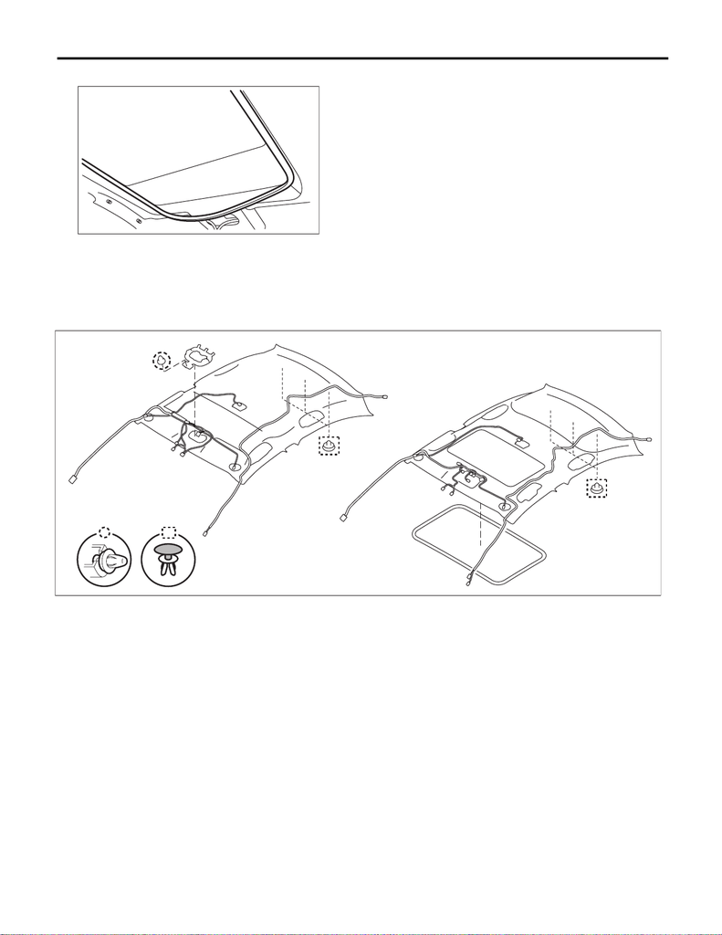

EI-100

Roof Trim

EXTERIOR/INTERIOR TRIM

14) Remove the garnish - roof. (Model with sunroof)

15) Remove the trim panel - roof assembly.

(1) Remove the harness clamp of the cord assembly - antenna feeder and the cord - roof, and disconnect

the connectors.

(2) Remove the clips and the Velcro tape behind the room light.

(3) Remove the weather strip - body side flange from the front/rear and left/right doors, and remove the

trim panel - roof assembly.

EI-02299

EI-04388

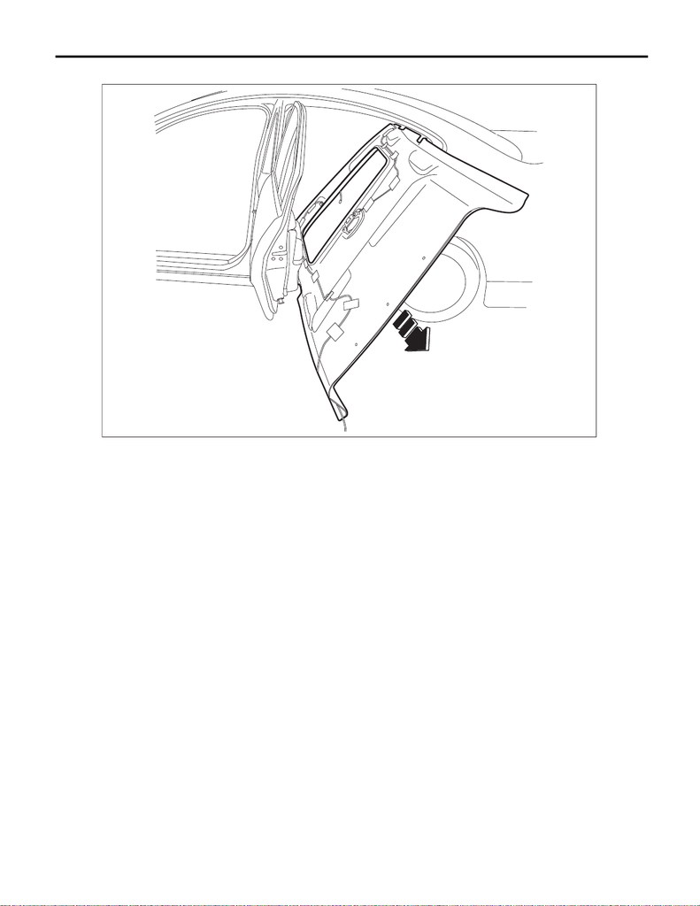

EI-101

Roof Trim

EXTERIOR/INTERIOR TRIM

(4) Take out the trim panel - roof assembly from the vehicle.

EI-03466

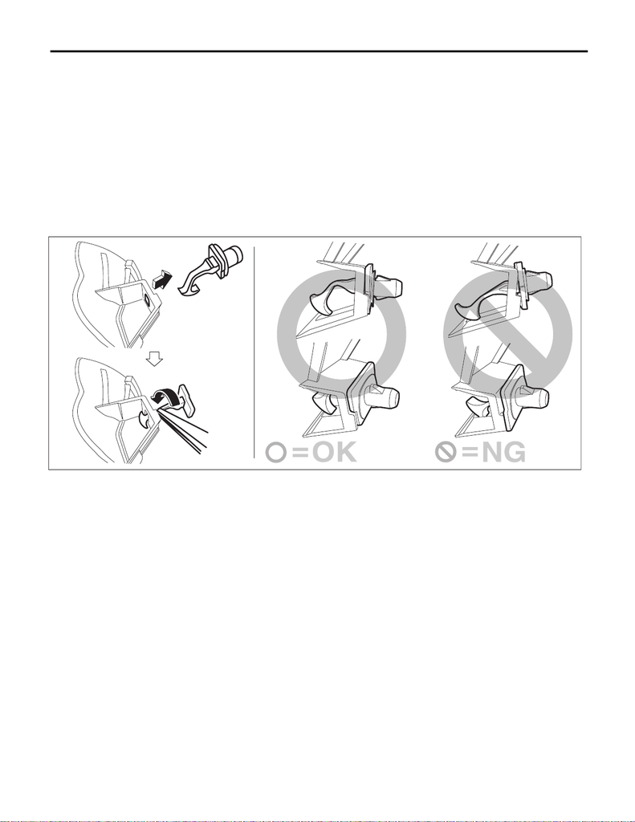

EI-102

Roof Trim

EXTERIOR/INTERIOR TRIM

B: INSTALLATION

CAUTION:

• When reusing the tether clip on the upper part of the trim panel - front pillar UPR, check that there

is no damage to the tether clip. If the clip is damaged, its holding force is reduced and the trim panel

- front pillar UPR may come off. Be sure to replace it with a new clip.

• Do not reuse the tether clip removed from the upper part of the trim panel - front pillar UPR. Always

replace with a new part.

• Do not reuse the upper clips of the trim panel - center pillar UPR. Once the clip is removed, its hold-

ing force is reduced. Be sure to replace it with a new clip.

• Before installing the trim panel - front pillar UPR, check the condition of protective non-woven fab-

ric (white) of the curtain airbag. If it is damaged (airbag module cloth is exposed), replace the curtain

airbag module assembly with a new part.

• Check the installation status of the tether clips and install the trim panel - front pillar UPR.

EI-03620

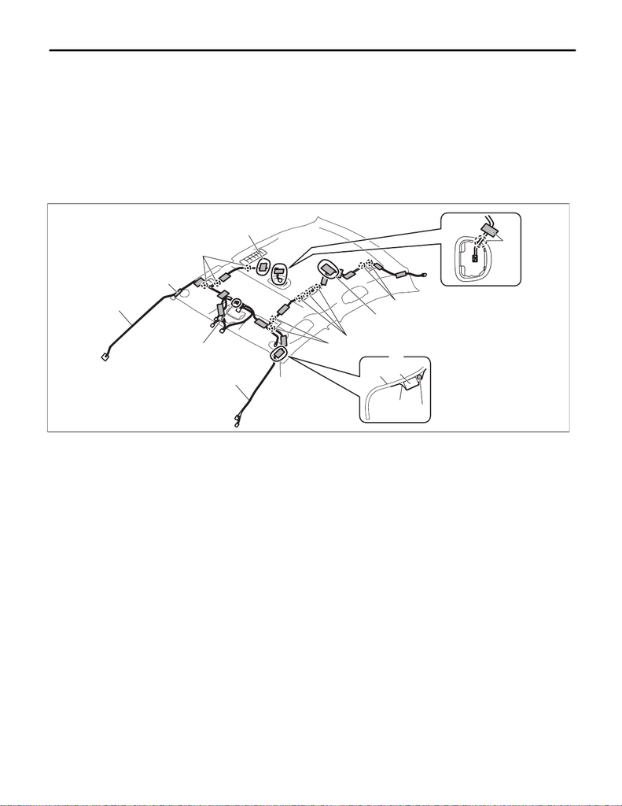

EI-103

Roof Trim

EXTERIOR/INTERIOR TRIM

1) Install the trim panel - roof assembly.

(1) Bring the trim panel - roof assembly inside the vehicle.

(2) Attach the feeder cord and roof cord to the roof trim.

CAUTION:

Route each cord carefully. The cord may interfere, thus preventing normal deployment of the curtain

airbag when necessary.

Tape:

Item number: 86359SC000/TAPE

NOTE:

Use the tape (service parts) by cutting into 100 mm × 50 mm (3.2 in × 2.0 in).

EI-04389

(a)

(b)

(d)

(c)

(3)

(4)

(5)

(2)

(g)

(d)

(c)

(c)

(c)

(1)

(2)

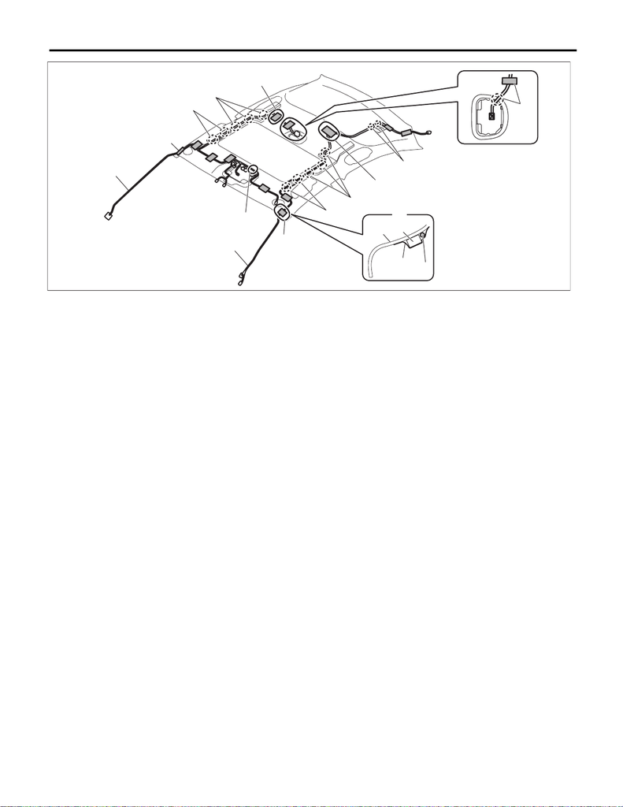

EI-104

Roof Trim

EXTERIOR/INTERIOR TRIM

(3) Secure the trim panel - roof assembly with the clips.

2) Install the garnish - roof. (Model with sunroof)

3) Install the assist rail.

4) Install the light assembly - room.

5) Install the sun visor assembly.

6) Install the light assembly - map.

7) Install the trim panel - rear pillar UPR.

8) Install the upper inner trim.

Tightening torque:

Trim panel - center pillar UPR: 7.5 N·m (0.8 kgf-m, 5.5 ft-lb)

Front seat belt anchor: 30 N·m (3.1 kgf-m, 22.1 ft-lb)

9) Install the lower inner trim.

10) Install the rear seat cushion assembly.

11) Install the console box assembly and cover - shift lever.

12) Install the driver’s seat.

Tightening torque:

53 N·m (5.4 kgf-m, 39.1 ft-lb)

13) Connect the battery ground terminal. <Ref. to NT-5, BATTERY, NOTE, Note.>

NOTE:

For models other than STI model, connect the ground terminal to battery sensor.

(1) Roof cord (3) Trim panel - roof (5) Tape

(2) Feeder cord (4) Cushion

(a) Align the center of the marking

(white tape) on the cord with the

trim end, then secure using the

tape.

(d) Adjust the excess cord at (d) posi-

tion and secure using the tape.

(g) Route the cord along inside of the

cushion (to the vehicle center) and

secure using the tape.

(b) Align the marking (white tape) of

the cord with the clamp to secure.

(e) Secure the marking (white tape) of

the cord using the tape so that the

marking cannot be viewed from

the passenger room.

(c) Secure the cord to the roof pad

clamp.

(f) Align the center of the marking

(red tape) on the cord with the roof

trim end, then secure using the

tape.

EI-04390

(4)

(5)

(2)

(a)

(b)

(c)

(e)

(d)

(d)

(c)

(c)

(c)

(g)

(c)

(1)

(2)